# Analysis of Electoral Bond Data

- As per instruction of the Honorable **Supreme Court of India**, the **State Bank of India** (SBI) has submitted all the data regarding *Electoral Bonds* to **Election Commission of India** on 21/03/2024.
- It includes the details of all bonds encashed between April 12, 2019, and January 24, 2024.
- This data is publicly available on the website of ECI at [www.eci.gov.in](https://www.eci.gov.in/disclosure-of-electoral-bonds)
  - Purchase_details (pdf)
  - Redemption_details (pdf)
  - These pdfs were converted to csv format using online utility and MS Excel
- In this notebook, I will analyze the data and try to answer some salient questions.

## Import necessary Libraries and Datasets

```python
# Importin necessary libraries
import pandas as pd # For data manipulation
import matplotlib.pyplot as plt # For data visualization
```

```python
# Importing purchse details dataset
purchase_df = pd.read_csv(r"data/subscriber_details.csv")

# Importing redemption details dataset
redeem_df = pd.read_csv(r"data/party_details.csv")
```

```python
# Let's check some sample rows from purchase_df
purchase_df.sample(3)
```

|  | Sr No. | Reference No (URN) | Journal Date | Date of\nPurchase | Date of Expiry | Name of the Purchaser | Prefix | Bond\nNumber | Denominations | Issue Branch Code | Issue Teller | Status |
| --- | --- | --- | --- | --- | --- | --- | --- | --- | --- | --- | --- | --- |
| 5166 | 5167 | 00001202107090000001896 | 09-Jul-2021 | 09-Jul-2021 | 23-Jul-2021 | MKJ ENTERPRISES LTD | OC | 8261 | 1,00,00,000 | 1 | 6405134 | Paid |
| 13291 | 13292 | 00800202304120000003002 | 12-Apr-2023 | 12-Apr-2023 | 26-Apr-2023 | BALAJI REAL ESTATE VENTURES PVT LT | TL | 152 | 10,00,000 | 800 | 7273126 | Paid |
| 6402 | 6403 | 00300202201040000002078 | 04-Jan-2022 | 04-Jan-2022 | 18-Jan-2022 | PRARAMBH SECURITIES PVT LTDPROPRIET | OC | 10033 | 1,00,00,000 | 300 | 7905165 | Paid |

```python
# Let's check some sample rows from redeem_df
redeem_df.sample(3)
```

|  | Sr No. | Date of\nEncashment | Name of the Political Party | Account no. of\nPolitical Party | Prefix | Bond\nNumber | Denominations | Pay Branch\nCode | Pay Teller |
| --- | --- | --- | --- | --- | --- | --- | --- | --- | --- |
| 6245 | 6246 | 13-Apr-2021 | PRESIDENT, ALL INDIA CONGRESS COMMITTEE | *******4012 | TL | 13912 | 10,00,000 | 691 | 7516991 |
| 6554 | 6555 | 13-Jul-2021 | ALL INDIA TRINAMOOL CONGRESS | *******0688 | TL | 14124 | 10,00,000 | 1 | 3480909 |
| 10418 | 10419 | 12-Apr-2022 | BHARAT RASHTRA SAMITHI | *******7477 | OC | 12004 | 1,00,00,000 | 847 | 3898296 |

## Data Information and Data Cleaning & Transformation

```python
# Checking columns and datatypes and shape
print("purchase_df ->\n", purchase_df.dtypes)
print(f"Rows = {purchase_df.shape[0]} | Columns = {purchase_df.shape[1]}")
print("-----------------------------------------")
print("redeem_df ->\n", redeem_df.dtypes)
print(f"Rows = {redeem_df.shape[0]} | Columns = {redeem_df.shape[1]}")
```

```
purchase_df ->
 Sr No.                    int64
Reference No  (URN)      object
Journal Date             object
Date of\nPurchase        object
Date of Expiry           object
Name of the Purchaser    object
Prefix                   object
Bond\nNumber              int64
Denominations            object
Issue Branch Code         int64
Issue Teller              int64
Status                   object
dtype: object
Rows = 18871 | Columns = 12
-----------------------------------------
redeem_df ->
 Sr No.                              int64
Date of\nEncashment                object
Name of the Political Party        object
Account no. of\nPolitical Party    object
Prefix                             object
Bond\nNumber                        int64
Denominations                      object
Pay Branch\nCode                    int64
Pay Teller                          int64
dtype: object
Rows = 20421 | Columns = 9
```

🔎 **Observations:**

- All the date columns are in `object/string` format which needs to be converted to `pandas.datetime`
- We want denomination in `int/float` form for making calculation. Also denomination unit needs to be in Cr which is suitable for aggregation.
- Bond Number should be converted to `object` because Prefix and Bond Number together gives a bond_id which can be used as unique identifier
- Some columns need renaming for easy access
- Columns to be deleted
  - Sr No, Reference No URN, Prefix, Bond\nNumber, Issue Branch Code, Issue Teller
  - Sr No, A/c no of Political party, Pay Branch code, Pay Teller

```python
# Delete unnecessary columns
purchase_df.drop(columns=["Sr No.", "Reference No  (URN)", "Issue Branch Code", "Issue Teller"], inplace=True)

redeem_df.drop(columns=["Sr No.", "Account no. of\nPolitical Party", "Pay Branch\nCode", "Pay Teller"], inplace=True)

# Renaming columns as required
purchase_df.rename(columns={'Journal Date': 'j_date',
                            'Date of\nPurchase': 'p_date',
                            'Date of Expiry': 'e_date',
                            'Name of the Purchaser': 'purchaser',
                            'Prefix': 'prefix',
                            'Bond\nNumber': 'bond_number',
                            'Denominations': 'denominations',
                            'Status': 'status'}, inplace=True)

redeem_df.rename(columns={'Date of\nEncashment': 'encash_date',
                        'Name of the Political Party': 'party',
                        'Prefix': 'prefix',
                        'Bond\nNumber': 'bond_number',
                        'Denominations': 'encash_denominations'}, inplace=True)

# Changing date format from object to pd.datetime
purchase_df["j_date"] = pd.to_datetime(purchase_df["j_date"])
purchase_df["p_date"] = pd.to_datetime(purchase_df["p_date"])
purchase_df["e_date"] = pd.to_datetime(purchase_df["e_date"])

redeem_df["encash_date"] = pd.to_datetime(redeem_df["encash_date"])

# Changing denominations format
purchase_df.denominations = purchase_df.denominations.str.replace(",", "").astype("int")

redeem_df.encash_denominations = redeem_df.encash_denominations.str.replace(",", "").astype("int")

# Setting denomination unit to cr
purchase_df.denominations = purchase_df.denominations/10000000

redeem_df.encash_denominations = redeem_df.encash_denominations/10000000

# create a new column bond_id by combining prefix and bond number
purchase_df["bond_id"] = purchase_df.apply(lambda row: row["prefix"] + str(row["bond_number"]), axis=1)

redeem_df["bond_id"] = redeem_df.apply(lambda row: row["prefix"] + str(row["bond_number"]), axis=1)

# Delete prefix and bond number
purchase_df.drop(columns=["prefix", "bond_number"], inplace=True)

redeem_df.drop(columns=["prefix", "bond_number"], inplace=True)
```

```python
# Checking columns and datatypes and shape after data cleaning
print("purchase_df ->\n", purchase_df.dtypes)
print(f"Rows = {purchase_df.shape[0]} | Columns = {purchase_df.shape[1]}")
print("-----------------------------------------")
print("redeem_df ->\n", redeem_df.dtypes)
print(f"Rows = {redeem_df.shape[0]} | Columns = {redeem_df.shape[1]}")
```

```
purchase_df ->
 j_date           datetime64[ns]
p_date           datetime64[ns]
e_date           datetime64[ns]
purchaser                object
denominations           float64
status                   object
bond_id                  object
dtype: object
Rows = 18871 | Columns = 7
-----------------------------------------
redeem_df ->
 encash_date             datetime64[ns]
party                           object
encash_denominations           float64
bond_id                         object
dtype: object
Rows = 20421 | Columns = 4
```

#### Q. What is time period of our data (period under consideration)?

```python
# Check time period of our data
print(f"purchase_df -> {min(purchase_df.p_date)} - {max(purchase_df.p_date)}")
print("-------------------------------")
print(f"redeem_df -> {min(redeem_df.encash_date)} - {max(redeem_df.encash_date)}")
```

```
purchase_df -> 2019-04-12 00:00:00 - 2024-01-11 00:00:00
-------------------------------
redeem_df -> 2019-04-12 00:00:00 - 2024-01-24 00:00:00
```

🔎 **Observations:**

- 12th April 2019 to 24th Jan 2024
- We have more data in redeem_df because bonds which were purchased earlier were redeemed during period under consideration.

## Explore `purchase_df`

```python
# some sample rows from purchase df
purchase_df.sample(4)
```

|  | j_date | p_date | e_date | purchaser | denominations | status | bond_id |
| --- | --- | --- | --- | --- | --- | --- | --- |
| 7434 | 2022-01-07 | 2022-01-07 | 2022-01-21 | CAPE TRADING LLP | 0.10 | Paid | TL13233 |
| 5685 | 2021-10-05 | 2021-10-05 | 2021-10-19 | TRANSWAYS EXIM PRIVATE LIMITED | 0.10 | Paid | TL14172 |
| 4811 | 2021-07-06 | 2021-07-06 | 2021-07-20 | AUSTIN PLYWOOD PRIVATE LIMITED FORMERLY B S P... | 0.01 | Paid | OL1387 |
| 6457 | 2022-01-05 | 2022-01-05 | 2022-01-19 | CHENNAI GREEN WOODS PRIVATE LIMITED | 1.00 | Paid | OC9612 |

#### Q. What is the total amount (in Cr) of bonds purchased during period of consideration?

```python
# Total denomination purchase during period of consideration
purchase_df.denominations.sum()
```

```
12155.5132
```

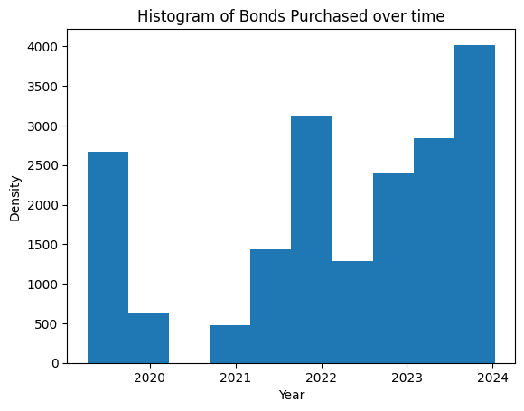

```python
# Let's check distribution of purchase over time
plt.hist(purchase_df.p_date)
plt.title("Histogram of Bonds Purchased over time", fontsize=12)
plt.xlabel("Year")
plt.ylabel("Density");
```

🔎 **Observations:**

- Decrease in bond purchase during covid period is evident.

#### Q. How many bonds expired? And the total amount of expired bonds?

```python
# Checking number of expired bonds
purchase_df.status.value_counts()
```

```
Paid       18741
Expired      130
Name: status, dtype: int64
```

```python
# Total amount of expired bonds in cr
purchase_df.groupby("status")["denominations"].sum()
```

```
status
Expired        9.6349
Paid       12145.8783
Name: denominations, dtype: float64
```

🔎 **Observations:**

- Out of 18871 purchased bonds, 130 bonds worth 9.63 Cr expired

#### Q. List the entities whose bonds expired?

```python
# Bonds of below purchasers expired
purchase_df[purchase_df.status == "Expired"].groupby("purchaser")["denominations"].sum().sort_values(ascending=False)
```

```
purchaser
FUTURE GAMING AND HOTEL SERVICES PR           3.0000
ECL FINANCE LTD                               2.0000
EDELWEISS RURAL   CORPORATE SERVICE           1.0000
PACIFICA DEVELOPERS P LTD REFLECTIO           0.7500
PACIFICA  INDIA  PROJECTS PVT LTD             0.5000
SYLVANUS BUILDERS AND DEVELOPERS LI           0.5000
C MACKERTICH PVT LTD                          0.4000
VEDANTA LTD                                   0.3000
SUDHA COMMERCIAL COMPANY LTD                  0.3000
JUPITER MERCANTILES PVT LTD                   0.2500
UTKAL ALUMINA INTERNATIONAL LIMITED           0.2000
KEYSTONE REALTORS PVT LTD                     0.1000
V M SALGAOCAR CORPORATION PVT LTD             0.1000
CHENNAMANAGATHIHALLI SOLAR POWER PROJECT      0.0600
BRINDABAN NASKAR                              0.0500
SAROJIT KUMAR DEY                             0.0500
DIPAN  P  SHAH                                0.0300
PRAKASH DISTILLERY & CHEMICAL CO (P) LT  D    0.0300
RAKESH PRAVINCHANDRA SHAH                     0.0100
ANAND AGRAWAL                                 0.0025
RITESH AGARWAL                                0.0005
MR. ABHIJEET SOLOMAN KAMBLE                   0.0004
MR GIRIDARAN MANIVANNAN                       0.0003
MR. BISWAJIT  GHOSH                           0.0002
RAY CONSTRUCTIONS LTD                         0.0001
ADWITA FINVEST PRIVATE LIMITED                0.0001
PUNIT DEVENDRABHAI BHANDERI                   0.0001
POONAM AGARWAL                                0.0001
PAWAN AGARWAL                                 0.0001
N RAMAMOORTHY                                 0.0001
KUNAL GUPTA                                   0.0001
DAMINI NATH                                   0.0001
ANKUR SINGHAL S O SH  ANIL SIN                0.0001
MR. SAMEER  BHATIA                            0.0001
Name: denominations, dtype: float64
```

🔑 **Note:**

- Upon exploration it is observed that, "FUTURE GAMING" appears with 3 different names, hence I will replace those entries with "FUTURE GAMING AND HOTEL SERVICES"

```python
# future gaming appears with 3 different names in dataset
purchase_df[purchase_df["purchaser"].str.startswith("FUTURE GAMING")].purchaser.unique()
```

```
array(['FUTURE GAMING AND HOTEL SERVICES PR',
       'FUTURE GAMING AND HOTEL SERVICES PRIVATE LIMITED',
       'FUTURE GAMING AND HOTEL SERVICES PVT LTD'], dtype=object)
```

```python
# Replacing "Future Gaming" entries with "FUTURE GAMING AND HOTEL SERVICES"
purchase_df.purchaser = purchase_df.purchaser.apply(lambda x: "FUTURE GAMING AND HOTEL SERVICES"\
                                           if x.startswith("FUTURE GAMING") else x)
```

#### Q. How many different entities purchased Electoral Bonds?

```python
# How many unique purchasers are there?
purchase_df.purchaser.nunique()
```

```
1318
```

#### Q. List top 20 entities based on total denomination

```python
# Top 20 purchasers
purchaser_total = pd.DataFrame(purchase_df.groupby("purchaser")["denominations"].sum())
purchaser_total["%"] = purchaser_total.denominations*100/purchaser_total.denominations.sum()
purchaser_total.sort_values(by="%", ascending=False)[:20].apply(lambda x: round(x, 2))
```

| purchaser | denominations | % |
| --- | --- | --- |
| FUTURE GAMING AND HOTEL SERVICES | 1368.00 | 11.25 |
| MEGHA ENGINEERING AND INFRASTRUCTURES LI MITED | 821.00 | 6.75 |
| QWIKSUPPLYCHAINPRIVATELIMITED | 410.00 | 3.37 |
| HALDIA ENERGY LIMITED | 377.00 | 3.10 |
| VEDANTA LIMITED | 375.65 | 3.09 |
| ESSEL MINING AND INDS LTD | 224.50 | 1.85 |
| WESTERN UP POWER TRANSMISSION COMPANY LI MITED | 220.00 | 1.81 |
| KEVENTER FOODPARK INFRA LIMITED | 195.00 | 1.60 |
| MADANLAL LTD. | 185.50 | 1.53 |
| BHARTI AIRTEL LIMITED | 183.00 | 1.51 |
| YASHODA SUPER SPECIALITY HOSPITAL | 162.00 | 1.33 |
| UTKAL ALUMINA INTERNATIONAL LIMITED | 135.30 | 1.11 |
| DLF COMMERCIAL DEVELOPERS LIMITED | 130.00 | 1.07 |
| MKJ ENTERPRISES LIMITED | 128.35 | 1.06 |
| JINDAL STEEL AND POWER LIMITED | 123.00 | 1.01 |
| B G SHIRKE CONSTRUCTION TECHNOLOGY PVT L TD | 117.00 | 0.96 |
| DHARIWAL INFRASTRUCTURE LIMITED | 115.00 | 0.95 |
| CHENNAI GREEN WOODS PRIVATE LIMITED | 105.00 | 0.86 |
| BIRLACARBONINDIAPRIVATELIMITED | 105.00 | 0.86 |
| RUNGTA SONS P LTD | 100.00 | 0.82 |

```python
# Total percentage of top 5 purchasers
purchaser_total.sort_values(by="%", ascending=False)[:5]["%"].sum()
```

```
27.5730851084099
```

```python
#Total percentage of top 10 purchasers
purchaser_total.sort_values(by="%", ascending=False)[:10]["%"].sum()
```

```
35.86561857380073
```

```python
# Total percentage of top 20 purchasers
purchaser_total.sort_values(by="%", ascending=False)[:20]["%"].sum()
```

```
45.907563985040134
```

## Explore `redeem_df`

```python
# check sample 4 entires
redeem_df.sample(4)
```

|  | encash_date | party | encash_denominations | bond_id |
| --- | --- | --- | --- | --- |
| 9163 | 2022-01-14 | ALL INDIA TRINAMOOL CONGRESS | 1.0 | OC10146 |
| 8677 | 2022-01-12 | BHARATIYA JANATA PARTY | 0.1 | TL7196 |
| 18492 | 2023-11-13 | BHARATIYA JANATA PARTY | 1.0 | OC14263 |
| 918 | 2019-04-16 | BHARATIYA JANATA PARTY | 0.1 | TL12853 |

#### Q. How many parties have received funding through electoral bonds?

```python
# How many parties?
redeem_df.party.nunique()
```

```
24
```

#### Q. List parties and aggregate donation received and % of total donation?

```python
# partywise donations received via electoral bonds
party_df = pd.DataFrame(redeem_df.groupby("party")["encash_denominations"].sum().sort_values(ascending=False))
party_df["%"] = party_df.encash_denominations*100/ party_df.encash_denominations.sum()
party_df.apply(lambda x: round(x, 2))
```

| party | encash_denominations | % |
| --- | --- | --- |
| BHARATIYA JANATA PARTY | 6060.51 | 47.46 |
| ALL INDIA TRINAMOOL CONGRESS | 1609.53 | 12.60 |
| PRESIDENT, ALL INDIA CONGRESS COMMITTEE | 1421.87 | 11.14 |
| BHARAT RASHTRA SAMITHI | 1214.71 | 9.51 |
| BIJU JANATA DAL | 775.50 | 6.07 |
| DRAVIDA MUNNETRA KAZHAGAM (DMK) | 639.00 | 5.00 |
| YSR CONGRESS PARTY (YUVAJANA SRAMIKA RYTHU CONGRESS PARTY) | 337.00 | 2.64 |
| TELUGU DESAM PARTY | 218.88 | 1.71 |
| SHIVSENA | 159.38 | 1.25 |
| RASHTRIYA JANTA DAL | 73.50 | 0.58 |
| AAM AADMI PARTY | 65.45 | 0.51 |
| JANATA DAL ( SECULAR ) | 43.50 | 0.34 |
| SIKKIM KRANTIKARI MORCHA | 36.50 | 0.29 |
| NATIONALIST CONGRESS PARTY MAHARASHTRA PRADESH | 31.00 | 0.24 |
| JANASENA PARTY | 21.00 | 0.16 |
| ADYAKSHA SAMAJVADI PARTY | 14.05 | 0.11 |
| BIHAR PRADESH JANTA DAL(UNITED) | 14.00 | 0.11 |
| JHARKHAND MUKTI MORCHA | 13.50 | 0.11 |
| SHIROMANI AKALI DAL | 7.26 | 0.06 |
| ALL INDIA ANNA DRAVIDA MUNNETRA KAZHAGAM | 6.05 | 0.05 |
| SIKKIM DEMOCRATIC FRONT | 5.50 | 0.04 |
| MAHARASHTRAWADI GOMNTAK PARTY | 0.55 | 0.00 |
| JAMMU AND KASHMIR NATIONAL CONFERENCE | 0.50 | 0.00 |
| GOA FORWARD PARTY | 0.35 | 0.00 |

🔎 **Observations:**

- Out of 24 parties, BHARATIYA JANATA PARTY has received maximum donation through electoral bonds 6060.5 Cr which is ~ 47%.
- BJP is followed by TMC and INC who received 1609 Cr (12.60%) and 1422 Cr (11.13%) respectively.

#### Q. Plot suitable charts showing total redemption and their percentage?

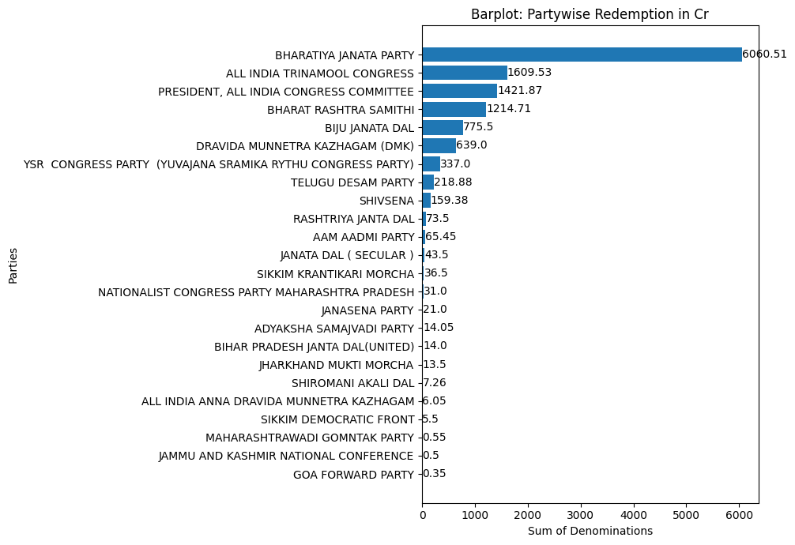

```python
# Bar plot of partywise donation received
plt.figure(figsize=(10,7))
x = plt.barh(y=party_df.index, width=party_df.encash_denominations)
plt.title("Barplot: Partywise Redemption in Cr", fontsize=12)
plt.xlabel("Sum of Denominations")
plt.ylabel("Parties")
plt.bar_label(container=x, labels=round(party_df.encash_denominations, 2))
plt.gca().invert_yaxis()
plt.tight_layout()
plt.savefig("partywise_donation_sum.png", dpi=400);
```

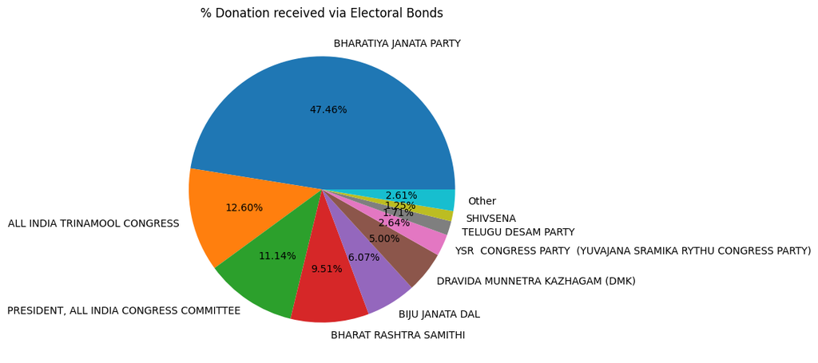

```python
# Let's plot pie chart, aggregating parties who received less than 100cr as others
y = party_df[party_df.encash_denominations<100].encash_denominations.sum()
x = party_df[party_df.encash_denominations>100].encash_denominations
pd.set_option('mode.chained_assignment', None)
x.loc["Other"] = y
plt.figure(figsize=(10,6))
plt.pie(x, labels=x.index, autopct="%.2f%%")
plt.title("% Donation received via Electoral Bonds", fontsize=12)
plt.savefig("partywise_pie.png", dpi=400);
```

#### Q. Create a table showing parties, agg redemption per year and total redemption.

```python
# adding 'year' column for yearwise comparison
redeem_df["encash_year"] = redeem_df["encash_date"].dt.year

# Create a pivot table of yearwise donations received by parties
party_year = redeem_df.pivot_table(index="party", columns="encash_year",
                                   values="encash_denominations", aggfunc="sum")

# Merging partywise total to pivot table
party_year_total = party_year.merge(party_df["encash_denominations"], right_on=party_df.index, left_on=party_year.index)\
                .sort_values(by="encash_denominations", ascending=False).set_index("key_0")
party_year_total.apply(lambda x: round(x, 2))
```

| key_0 | 2019 | 2020 | 2021 | 2022 | 2023 | 2024 | encash_denominations |
| --- | --- | --- | --- | --- | --- | --- | --- |
| BHARATIYA JANATA PARTY | 1971.75 | 73.89 | 373.00 | 1763.55 | 1676.33 | 202.00 | 6060.51 |
| ALL INDIA TRINAMOOL CONGRESS | 87.09 | 29.77 | 330.94 | 468.80 | 562.47 | 130.45 | 1609.53 |
| PRESIDENT, ALL INDIA CONGRESS COMMITTEE | 170.31 | 9.00 | 123.92 | 289.36 | 793.37 | 35.90 | 1421.87 |
| BHARAT RASHTRA SAMITHI | 37.15 | NaN | 153.00 | 528.99 | 495.57 | NaN | 1214.71 |
| BIJU JANATA DAL | 10.00 | 77.00 | 241.00 | 195.00 | 252.50 | NaN | 775.50 |
| DRAVIDA MUNNETRA KAZHAGAM (DMK) | 9.00 | 80.00 | 205.00 | 285.00 | 40.00 | 20.00 | 639.00 |
| YSR CONGRESS PARTY (YUVAJANA SRAMIKA RYTHU CONGRESS PARTY) | 8.25 | 89.00 | 66.25 | 52.00 | 118.50 | 3.00 | 337.00 |
| TELUGU DESAM PARTY | 7.30 | NaN | 3.50 | 13.00 | 76.88 | 118.20 | 218.88 |
| SHIVSENA | 33.38 | NaN | NaN | 29.00 | 72.00 | 25.00 | 159.38 |
| RASHTRIYA JANTA DAL | 2.50 | 1.00 | NaN | NaN | 55.00 | 15.00 | 73.50 |
| AAM AADMI PARTY | 2.20 | 3.30 | 1.85 | 47.95 | 10.15 | NaN | 65.45 |
| JANATA DAL ( SECULAR ) | 2.50 | NaN | NaN | NaN | 41.00 | NaN | 43.50 |
| SIKKIM KRANTIKARI MORCHA | NaN | NaN | NaN | 2.00 | 31.50 | 3.00 | 36.50 |
| NATIONALIST CONGRESS PARTY MAHARASHTRA PRADESH | 15.50 | NaN | 3.80 | 10.20 | 1.50 | NaN | 31.00 |
| JANASENA PARTY | NaN | NaN | NaN | 2.00 | 2.00 | 17.00 | 21.00 |
| ADYAKSHA SAMAJVADI PARTY | 10.84 | NaN | NaN | 3.21 | NaN | NaN | 14.05 |
| BIHAR PRADESH JANTA DAL(UNITED) | 3.00 | 1.00 | NaN | 10.00 | NaN | NaN | 14.00 |
| JHARKHAND MUKTI MORCHA | 1.00 | NaN | NaN | NaN | 12.50 | NaN | 13.50 |
| SHIROMANI AKALI DAL | 6.76 | NaN | NaN | 0.50 | NaN | NaN | 7.26 |
| ALL INDIA ANNA DRAVIDA MUNNETRA KAZHAGAM | 6.05 | NaN | NaN | NaN | NaN | NaN | 6.05 |
| SIKKIM DEMOCRATIC FRONT | NaN | NaN | NaN | NaN | 5.00 | 0.50 | 5.50 |
| MAHARASHTRAWADI GOMNTAK PARTY | NaN | NaN | NaN | 0.55 | NaN | NaN | 0.55 |
| JAMMU AND KASHMIR NATIONAL CONFERENCE | 0.50 | NaN | NaN | NaN | NaN | NaN | 0.50 |
| GOA FORWARD PARTY | NaN | NaN | NaN | 0.35 | NaN | NaN | 0.35 |

#### Q. Plot redemption trendline for Top 5 parties

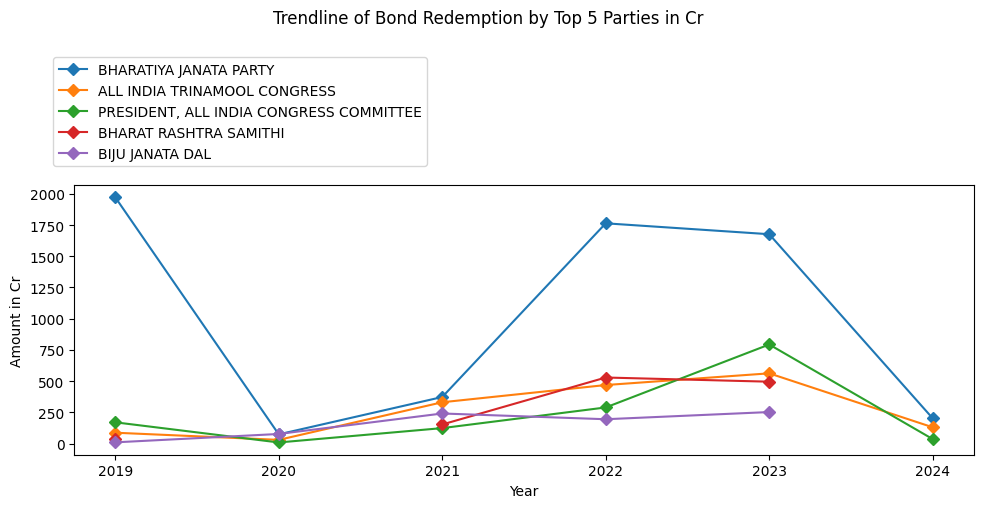

```python
# Plotting yearwise donation received for top 5 parties
party_top_5 = party_year_total.iloc[:5, :-1].T
plt.figure(figsize=(10,6))
plt.plot(party_top_5, marker="D")
plt.legend(party_top_5.columns, bbox_to_anchor=(0.4, 1.5), loc='upper right')
plt.suptitle("Trendline of Bond Redemption by Top 5 Parties in Cr", fontsize=12, y=0.84)
plt.xlabel("Year")
plt.ylabel("Amount in Cr")
plt.tight_layout()
plt.savefig("trend_top_5.png", dpi=400);
```

## Merge `purchase_df` and `redeem_df` using `bond_id`

```python
# Merge our two datasets
merged_df = pd.merge(purchase_df, redeem_df[["bond_id", "party", "encash_date", "encash_denominations"]], on="bond_id")
merged_df.head(3)
```

|  | j_date | p_date | e_date | purchaser | denominations | status | bond_id | party | encash_date | encash_denominations |
| --- | --- | --- | --- | --- | --- | --- | --- | --- | --- | --- |
| 0 | 2019-04-12 | 2019-04-12 | 2019-04-26 | A B C INDIA LIMITED | 0.1 | Paid | TL11448 | BHARATIYA JANATA PARTY | 2019-04-25 | 0.1 |
| 1 | 2019-04-12 | 2019-04-12 | 2019-04-26 | A B C INDIA LIMITED | 0.1 | Paid | TL11447 | BHARATIYA JANATA PARTY | 2019-04-25 | 0.1 |
| 2 | 2019-04-12 | 2019-04-12 | 2019-04-26 | A B C INDIA LIMITED | 0.1 | Paid | TL11441 | BHARATIYA JANATA PARTY | 2019-04-25 | 0.1 |

```python
# Data validation for merged df
print(f"Status value_counts: {merged_df.status.value_counts()}")
print(f"If purchase denominations are equal to encash_denomination? Matching rows \
-> {(merged_df.denominations == merged_df.encash_denominations).sum()}")
print(f"If encash date is later to purchase date? Matching rows \
-> {(merged_df.encash_date >= merged_df.p_date).sum()}")
```

```
Status value_counts: Paid    18741
Name: status, dtype: int64
If purchase denominations are equal to encash_denomination? Matching rows -> 18741
If encash date is later to purchase date? Matching rows -> 18741
```

🔎 **Observations:**

- We have found 18741 matching entries, after merging 2 datasets

#### Q. List Top 10 Donors for Top 5 parties

```python
# A function to print top donors with respect to parties
def give_top_donors(party, df=merged_df, top=10):
    df_party = df[df.party == party].groupby("purchaser").denominations.sum()
    print(df_party.sort_values(ascending=False)[:top])
```

```python
# Lets get top 10 donors of top 5 parties
for party in party_df.index[:5]:
    print(f"-----------{party}-------------")
    give_top_donors(party, df=merged_df, top=10)
    print("\n")
print("Note: Amount in Cr")
```

```
-----------BHARATIYA JANATA PARTY-------------
purchaser
MEGHA ENGINEERING AND INFRASTRUCTURES LI MITED    519.00
QWIKSUPPLYCHAINPRIVATELIMITED                     375.00
VEDANTA LIMITED                                   226.65
BHARTI AIRTEL LIMITED                             183.00
MADANLAL LTD.                                     175.50
KEVENTER FOODPARK INFRA LIMITED                   144.50
DLF COMMERCIAL DEVELOPERS LIMITED                 130.00
BIRLACARBONINDIAPRIVATELIMITED                    105.00
FUTURE GAMING AND HOTEL SERVICES                  100.00
HALDIA ENERGY LIMITED                              81.00
Name: denominations, dtype: float64


-----------ALL INDIA TRINAMOOL CONGRESS-------------
purchaser
FUTURE GAMING AND HOTEL SERVICES       542.0
HALDIA ENERGY LIMITED                  281.0
DHARIWAL INFRASTRUCTURE LIMITED         90.0
IFB AGRO INDUSTRIES LIMITED             42.0
PCBL LIMITED                            40.0
CHENNAI GREEN WOODS PRIVATE LIMITED     40.0
PRARAMBH SECURITIES PVT LTDPROPRIET     38.0
CRESCENT POWER LTD                      33.0
MKJ ENTERPRISES LTD                     27.4
AVEES TRADING & FINANCE PVT LTD         24.0
Name: denominations, dtype: float64


-----------PRESIDENT, ALL INDIA CONGRESS COMMITTEE-------------
purchaser
WESTERN UP POWER TRANSMISSION COMPANY LI MITED    110.00
VEDANTA LIMITED                                   104.00
MKJ ENTERPRISES LIMITED                            69.35
YASHODA SUPER SPECIALITY HOSPITAL                  64.00
AVEES TRADING FINANCE PVT LTD                      53.00
FUTURE GAMING AND HOTEL SERVICES                   50.00
SASMAL INFRASTRUCTURE PRIVATE LIMITED              39.00
RITHWIK PROJECTS  PRIVATE LIMITED                  30.00
```

[output cut: 21 more lines]

```
purchaser
ESSEL MINING AND INDS LTD              174.5
JINDAL STEEL AND POWER LIMITED         100.0
UTKAL ALUMINA INTERNATIONAL LIMITED     60.0
RUNGTA SONS P LTD                       50.0
RASHMI CEMENT LTD                       45.0
MS S N MOHANTY                          45.0
VEDANTA LIMITED                         40.0
JINDAL STAINLESS LTD                    30.0
PENGUIN TRADING & AGENCIES LIMITED      27.5
RASHMI METALIKS LTD                     27.0
Name: denominations, dtype: float64


Note: Amount in Cr
```

#### Q. Plot how Top 10 purchasers donated electoral bonds.

```python
# dictionary of political parties and short name (generated from ChatGPT)
party_name_dict = {
  "ALL INDIA ANNA DRAVIDA MUNNETRA KAZHAGAM": "AIADMK",
  "BHARAT RASHTRA SAMITHI": "BRS",
  "BHARATIYA JANATA PARTY": "BJP",
  "PRESIDENT, ALL INDIA CONGRESS COMMITTEE": "INC",
  "SHIVSENA": "Shiv Sena",
  "TELUGU DESAM PARTY": "TDP",
  "YSR  CONGRESS PARTY  (YUVAJANA SRAMIKA RYTHU CONGRESS PARTY)": "YSRCP",
  "DRAVIDA MUNNETRA KAZHAGAM (DMK)": "DMK",
  "JANATA DAL ( SECULAR )": "JD(S)",
  "NATIONALIST CONGRESS PARTY MAHARASHTRA PRADESH": "NCP",
  "ALL INDIA TRINAMOOL CONGRESS": "TMC",
  "BIHAR PRADESH JANTA DAL(UNITED)": "JD(U)",
  "RASHTRIYA JANTA DAL": "RJD",
  "AAM AADMI PARTY": "AAP",
  "ADYAKSHA SAMAJVADI PARTY": "SP",
  "SHIROMANI AKALI DAL": "SAD",
  "JHARKHAND MUKTI MORCHA": "JMM",
  "JAMMU AND KASHMIR NATIONAL CONFERENCE": "JKNC",
  "BIJU JANATA DAL": "BJD",
  "GOA FORWARD PARTY": "GFP",
  "MAHARASHTRAWADI GOMNTAK PARTY": "MGP",
  "SIKKIM KRANTIKARI MORCHA": "SKM",
  "JANASENA PARTY": "JSP",
  "SIKKIM DEMOCRATIC FRONT": "SDF"
}
```

```python
# We need party short names for plotting them as legend
x = merged_df.copy()
x.party = x.party.apply(lambda x: party_name_dict.get(x))
```

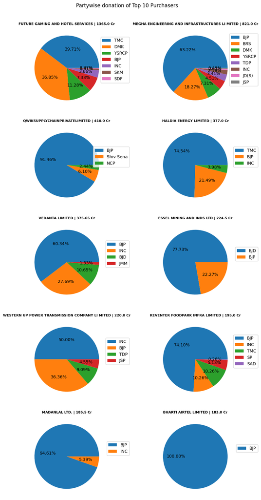

```python
# Top 10 purchasers - partywise pie plot
top_purchasers = purchaser_total["denominations"].sort_values(ascending=False)[:10]

plt.figure(figsize=(10,20))
for i in range(10):
    plt.subplot(5,2,i+1)
    y = x[x.purchaser == top_purchasers.index[i]]
    y = y.groupby("party")["denominations"].sum().sort_values(ascending=False)
    plt.pie(y, autopct="%.2f%%")
    plt.title(f"{top_purchasers.index[i]} | {y.sum()} Cr", fontsize=8, fontweight="bold")
    plt.legend(y.index, bbox_to_anchor = (1.30, 0.6), loc='center right')
plt.suptitle("Partywise donation of Top 10 Purchasers", y=0.92, fontsize=12)
plt.savefig("top_10_purchaser_donation.png", dpi=400);
```

🔑 Note:

- More insgihts can be generated if we could classify Purchasing Entities into
  - Individual purchasers
  - Corporate
    - Pharma companies
    - Telecom companies
    - Infrastructure companies
    - Manufacturing companies
    - Hospital Chains
    - IT/ Service based companies